# California Housing Analysis

Grace Lippert

2026-06-09

# 1 Introduction

## 1.1 Background and Dataset Information

The dataset used for this analysis comes from the 1990 California census and contains 20,640 observations and 10 variables. Each of these observations represents several socio-economic features of a specific California block group. The variables within this dataset contain information regarding the longitude and latitude of the center of each block group, as well as the median age of housing units, total rooms, total bedrooms, population, households, median income, ocean proximity, and median house value of each block group. A complete table of the variables is listed below:

```r
data_dictionary <- tribble(
  ~Variable_Name,         ~Description,                                                                        ~Variable_Type,
  "[longitude]",          "[The longitude of the center of each block group]",                                 "[Numeric]",
  "[latitude]",           "[The latitude of the center of each block group]",                                  "[Numeric]",
  "[housing_median_age]", "[The median age of the housing units in each block (years)]",                       "[Numeric]",
  "[total_rooms]",        "[The total number of rooms in the housing units in each block group]",              "[Numeric]",
  "[total_bedrooms]",     "[The total number of bedrooms in the housing units in each block group]",           "[Numeric]",
  "[population]",         "[The total population of the block group]",                                         "[Numeric]",
  "[households]",         "[The total population of the block group]",                                         "[Numeric]",
  "[median_income]",      "[The median income of the block group (per month)]",                                "[Numeric]",
  "[ocean_proximity]",    "[The proximity of the block group to the ocean or other bodies of water (Near Bay, Inland, etc.)]",                                     "[Categorical]",
  "[median_house_value]", "[The median value of the housing units in the block group ($)]",                    "[Numeric]",

)

datatable(
  data_dictionary,
  caption = "Table 1: Variable definitions and types for the California analysis dataset",
  rownames = FALSE,
  options = list(pageLength = 10, dom = 'tip'))
```

| Variable_Name | Description | Variable_Type |
| --- | --- | --- |
| [longitude] | [The longitude of the center of each block group] | [Numeric] |
| [latitude] | [The latitude of the center of each block group] | [Numeric] |
| [housing_median_age] | [The median age of the housing units in each block (years)] | [Numeric] |
| [total_rooms] | [The total number of rooms in the housing units in each block group] | [Numeric] |
| [total_bedrooms] | [The total number of bedrooms in the housing units in each block group] | [Numeric] |
| [population] | [The total population of the block group] | [Numeric] |
| [households] | [The total population of the block group] | [Numeric] |
| [median_income] | [The median income of the block group (per month)] | [Numeric] |
| [ocean_proximity] | [The proximity of the block group to the ocean or other bodies of water (Near Bay, Inland, etc.)] | [Categorical] |
| [median_house_value] | [The median value of the housing units in the block group ($)] | [Numeric] |

## 1.2 Business Questions and Hypotheses:

This dataset will be used to answer the following set of practical questions:

**Question 1:** Is the median age of houses within a block group or median monthly income within a block group useful in predicting a block group’s median house value?

**Question 2:** Are the ratios of rooms to households, bedrooms to households, and population to households useful in predicting a block group’s median house value?

**Question 3:** Is a block group’s proximity to the ocean useful in predicting its median house value?

The hypotheses for these questions (based on current understanding before analysis) are listed below:

**Hypothesis 1:** Block groups that have a lower median household age and higher median monthly income will have a higher median house value given that newer homes tend to be more expensive and homeowners with a higher median monthly income would be able to afford more expensive homes.

**Hypotheses 2:** Block groups with a greater ratio of rooms to households, bedrooms to households, and population to households will have a higher median house value. Houses with more rooms and bedrooms tend to be more expensive, and a higher population (per household) could indicate the need for more space within a home and therefore may lead to homeowners purchasing a more expensive home.

**Hypotheses 3:** Block groups in closer proximity to the ocean will have a higher median house value. Ocean-side properties tend to be more expensive than properties further inland, which would impact median house value within a block group.

# 2 Data Quality, Distribution, and Relationship Assessment

## 2.1 Missing Values and Reformatting

Before moving on to further analyses, we will first consider the possibility of missing values and reformat several variabless in order to create a model that can more effectively predict median house value within block groups.

```r
setwd("C:/Users/grace/OneDrive/Stat Graduate Work/STA553 - Data Visualization")
housing <- read.csv("https://pengdsci.github.io/datasets/geocode/CaliforniaHousing/CaliforniaHousing.csv")
missing_summary <- summary(housing)
print(missing_summary)
```

```
##    longitude         latitude     housing_median_age  total_rooms
##  Min.   :-124.3   Min.   :32.54   Min.   : 1.00      Min.   :    2
##  1st Qu.:-121.8   1st Qu.:33.93   1st Qu.:18.00      1st Qu.: 1448
##  Median :-118.5   Median :34.26   Median :29.00      Median : 2127
##  Mean   :-119.6   Mean   :35.63   Mean   :28.64      Mean   : 2636
##  3rd Qu.:-118.0   3rd Qu.:37.71   3rd Qu.:37.00      3rd Qu.: 3148
##  Max.   :-114.3   Max.   :41.95   Max.   :52.00      Max.   :39320
##
##  total_bedrooms     population      households     median_income
##  Min.   :   1.0   Min.   :    3   Min.   :   1.0   Min.   : 0.4999
##  1st Qu.: 296.0   1st Qu.:  787   1st Qu.: 280.0   1st Qu.: 2.5634
##  Median : 435.0   Median : 1166   Median : 409.0   Median : 3.5348
##  Mean   : 537.9   Mean   : 1425   Mean   : 499.5   Mean   : 3.8707
##  3rd Qu.: 647.0   3rd Qu.: 1725   3rd Qu.: 605.0   3rd Qu.: 4.7432
##  Max.   :6445.0   Max.   :35682   Max.   :6082.0   Max.   :15.0001
##  NA's   :207
##  median_house_value ocean_proximity
##  Min.   : 14999     Length:20640
##  1st Qu.:119600     Class :character
##  Median :179700     Mode  :character
##  Mean   :206856
##  3rd Qu.:264725
##  Max.   :500001
##
```

```r
colSums(is.na(housing))
```

```
##          longitude           latitude housing_median_age        total_rooms
##                  0                  0                  0                  0
##     total_bedrooms         population         households      median_income
##                207                  0                  0                  0
## median_house_value    ocean_proximity
##                  0                  0
```

There are several missing values present within the ‘[total_bedrooms]’ variable. Given the dataset’s large sample size (20,640), we should be able to remove the 207 missing values without meaningfully impacting the results of our analysis. This means that our final dataset will have a total of 20,433 observations.

```r
housing <- na.omit(housing)
```

Next we will reformat several variables so that they are more accurate predictors of the target variable ’[median_house_value’]. While considering the total number of rooms, bedrooms, and population within each block group could be useful in its own right, we will instead consider the ratio of rooms to households, bedrooms to households, and population to households as these variables may be a more accurate predictors of a block group’s median house value.

```r
housing$rooms_per_house <- housing$total_rooms / housing$households

housing$bedrooms_per_house <- housing$total_bedrooms / housing$households

housing$population_per_house <-  housing$population / housing$households
```

These new variables are listed below:

```r
data_dictionary <- tribble(
  ~Variable_Name,            ~Description,                                                                        ~Variable_Type,
  "[rooms_per_house]",       "[The average number of rooms per house within a block group]",                      "[Numeric]",
  "[bedrooms_per_house]",    "[The average number of bedrooms per house within a block group]",                   "[Numeric]",
  "[population_per_house]",  "[The average population per house within a block group]",                           "[Numeric]",

)

datatable(
  data_dictionary,
  caption = "Table 2: Additional variable definitions and types for the California analysis dataset",
  rownames = FALSE,
  options = list(pageLength = 10, dom = 'tip'))
```

| Variable_Name | Description | Variable_Type |
| --- | --- | --- |
| [rooms_per_house] | [The average number of rooms per house within a block group] | [Numeric] |
| [bedrooms_per_house] | [The average number of bedrooms per house within a block group] | [Numeric] |
| [population_per_house] | [The average population per house within a block group] | [Numeric] |

## 2.2 Distribution Analysis

We will begin by examining the frequency distribution of our categorical variable, ‘[ocean_proximity]’. Examining this distribution will allow us to identify any categories that contain too few values to meaningfully analyze.

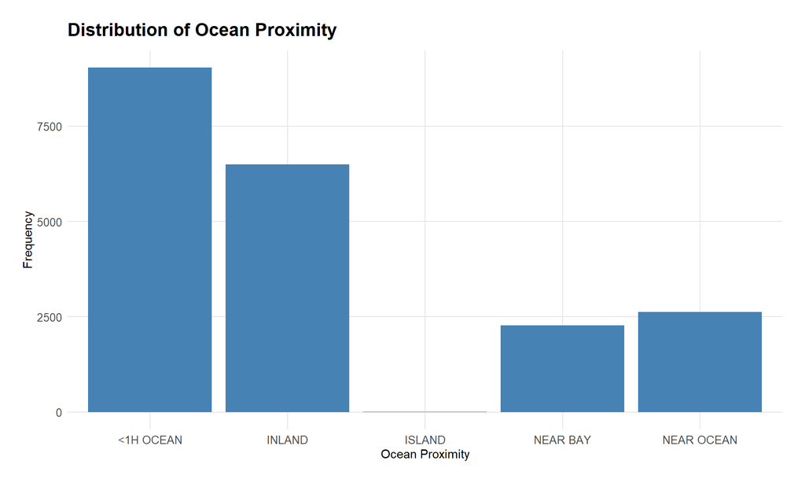

```r
ggplot(housing, aes(x = ocean_proximity)) +
  geom_bar(fill = "steelblue") +
  labs(
    title = "Distribution of Ocean Proximity",
    x = "Ocean Proximity",
    y = "Frequency"
  ) +
theme_storytelling
```

As we can see in the above barplot, there are relatively few observations within the ‘Island’ category in the ‘[ocean_proximity]’ variable. Given this, we will combine this category with the ‘Near Ocean’ category in order to make a single ‘Near Ocean and Island’ category.

```r
housing$ocean_proximity[housing$ocean_proximity %in% c("NEAR OCEAN", "ISLAND")
] <- "NEAR OCEAN AND ISLAND"
```

The final barplot (after combining ‘Near Ocean’ and ‘Island’) can be seen below:

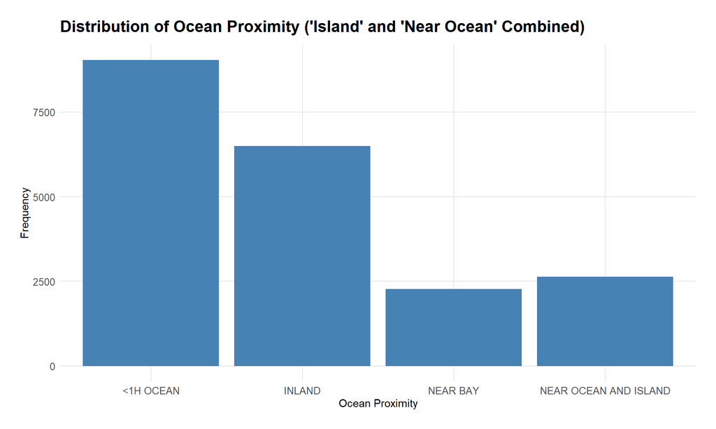

```r
ggplot(housing, aes(x = ocean_proximity)) +
  geom_bar(fill = "steelblue") +
  labs(
    title = "Distribution of Ocean Proximity ('Island' and 'Near Ocean' Combined)",
    x = "Ocean Proximity",
    y = "Frequency"
  ) +
theme_storytelling
```

Next we will consider the distributions of the numeric variables in the dataset. Understanding the shape, spread, and skewness of these variables can help us identify unusual patterns and outliers that may need to be taken into account when considering future modeling.

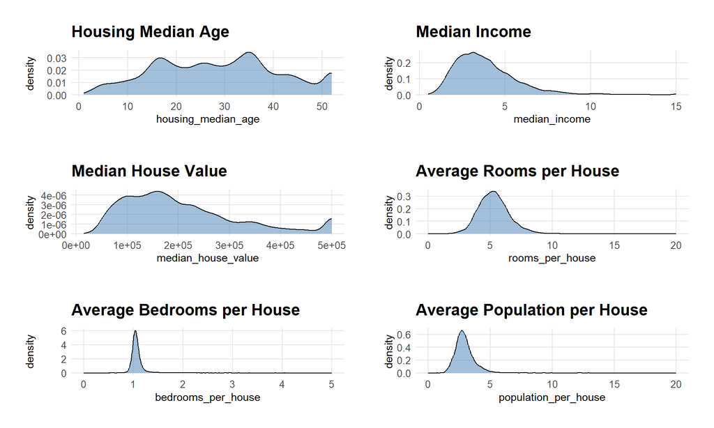

```r
p1 <- ggplot(housing, aes(x = housing_median_age)) +
  geom_density(fill = "steelblue", alpha = 0.5) +
  theme_storytelling +
  labs(title = "Housing Median Age")
p2 <- ggplot(housing, aes(x = median_income)) +
  geom_density(fill = "steelblue", alpha = 0.5) +
  theme_storytelling +
  labs(title = "Median Income")
p3 <- ggplot(housing, aes(x = median_house_value)) +
  geom_density(fill = "steelblue", alpha = 0.5) +
  theme_storytelling +
  labs(title = "Median House Value")
p4 <- ggplot(housing, aes(x = rooms_per_house)) +
  geom_density(fill = "steelblue", alpha = 0.5) +
  theme_storytelling +
  labs(title = "Average Rooms per House") + xlim(0, 20)
p5 <- ggplot(housing, aes(x = bedrooms_per_house)) +
  geom_density(fill = "steelblue", alpha = 0.5) +
  theme_storytelling +
  labs(title = "Average Bedrooms per House") + xlim(0, 5)
p6 <- ggplot(housing, aes(x = population_per_house)) +
  geom_density(fill = "steelblue", alpha = 0.5) +
  theme_storytelling +
  labs(title = "Average Population per House") + xlim(0, 20)

(p1 | p2) /
(p3 | p4) /
(p5 | p6)
```

Average rooms per house, average bedrooms per house, and average population per house all appear to be right-skewed unimodal distributions. This indicates that block groups tend to have a lower room to house, bedroom to house, and population to house ratios with some bin groups having much higher outlier ratios. Median income is also a right-skewed unimodal distribution, indicating that most bin groups had lower median monthly incomes with a few bin groups having much higher median monthly incomes. Housing median age has a multimodal distibution that is much more evenly spread out, indicating that median house age varies widely across bin groups. Finally, the target variable, median house value, is also a multimodal, evenly spread out distribution, indicating that median house value varies widely as well.

Finally, we will address the distribution of our longitudinal and latitudinal variables. We will looking for any clusters that indicate that it would be beneficial to transform these variables into categorical variables for further analysis:

```r
leaflet(housing) %>%
  addTiles() %>%  # Add default OpenStreetMap tiles
  addCircleMarkers(
    lng = ~ longitude,
    lat = ~ latitude,
    radius = 2,
    color = "blue",
    fillOpacity = 0.5,
     popup = ~paste(
      "<b>🏠 Property Details</b><br>",
      "━━━━━━━━━━━━━━━━━━━<br>",
      "📍 Coordinates:", round(latitude, 4), ",", round(longitude, 4)
    )
  )
```

[interactive chart not shown]

As we can see in the above map, there do not appear to be any noticeable or meaningful clusters that could be used to categorize the location of each bin group. However, future analyses could be utilized to further determine the benefits of using this data within a predictive model.

## 2.3 Correlation between Numeric Variables

Finally, before assessing our questions and hypotheses, we will briefly consider the correlations between our numeric variables. The correlations between ‘[housing_median_age],’ ‘[median_income],’ ‘[rooms_per_house]’, ‘[bedrooms_per_house]’, and ‘[population_per_house]’ are represented in the figure below:

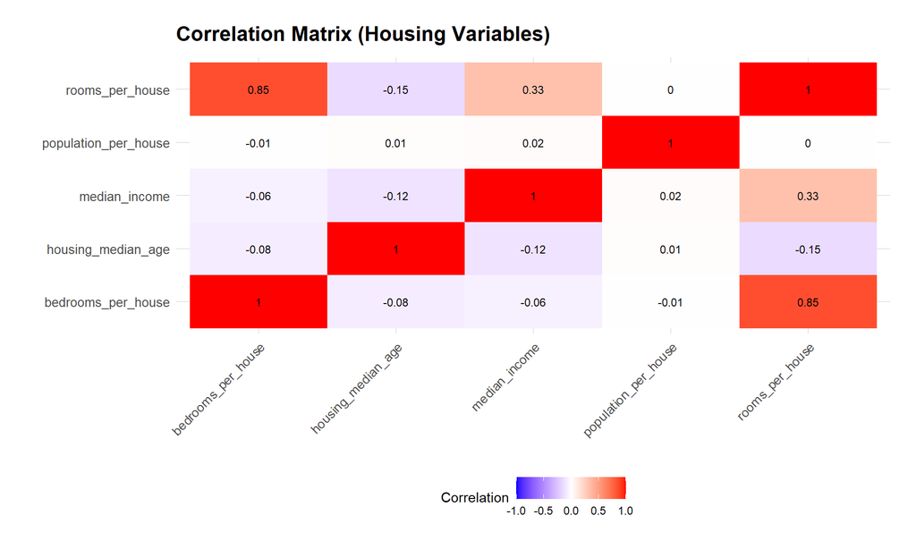

```r
vars <- housing[, c(
  "housing_median_age",
  "median_income",
  "rooms_per_house",
  "bedrooms_per_house",
  "population_per_house"
)]

cor_mat <- cor(vars, use = "complete.obs")

cor_df <- as.data.frame(cor_mat) %>%
  tibble::rownames_to_column("var1") %>%
  pivot_longer(-var1, names_to = "var2", values_to = "cor")

ggplot(cor_df, aes(x = var1, y = var2, fill = cor)) +
  geom_tile() +
   geom_text(aes(label = round(cor, 2)), size = 3) +
  scale_fill_gradient2(
    low = "blue",
    mid = "white",
    high = "red",
    limits = c(-1, 1)
  ) +
  theme_storytelling +
  labs(
    title = "Correlation Matrix (Housing Variables)",
    x = "",
    y = "",
    fill = "Correlation"
  ) +
  theme(axis.text.x = element_text(angle = 45, hjust = 1))
```

Most numeric variables exhibit weak correlations, which indicates that these variables measure distinct socio-economic features. However, there was a noticeably high correlation (r = 0.85) between ‘[rooms_per_house]’ and ‘[bedrooms_per_house]’. This makes practical sense, given that a higher number of bedrooms would directly contribute to a higher number of rooms in general. However, this would be important to keep in mind when considering future analyses.

# 3 Feature Engineering and Comparison

## 3.1 Descretizing Continous Variables

Before moving forward, we will discretize several continous variables into ordered categories. This transformation simplifies interpretation by allowing direct comparison between meaningful groups while reducing the influence of extreme observations. The resulting categories are also easier to visualize using boxplots.

```r
housing$housing_median_age.cat <- cut(housing$housing_median_age,
breaks = c(0, 10, 20, 30, 40, 50, Inf),
labels = c("0-10yr", "10-20yr", "20-30yr", "30-40yr", "40-50yr", "50yr+"))

housing$median_income.cat <-  cut(housing$median_income,
breaks = c(0, 2.5, 5, 7.5, Inf),
labels = c("0-2.5k", "2.5-5k", "5-7.5k", "7.5k+"))

housing$rooms_per_house.cat <-  cut(housing$rooms_per_house,
breaks = c(0, 2.5, 5, 7.5, Inf),
labels = c("0-2.5rm", "2.5-5rm", "5-7.5rm", "7.5rm+"))

housing$bedrooms_per_house.cat <- cut(housing$bedrooms_per_house,
breaks = c(0, 1, 2, Inf),
labels = c("0-1rm", "1-2rm", "2rm+"),
include.lowest = TRUE)

housing$population_per_house.cat <- cut(housing$population_per_house,
breaks = c(0, 2.5, 5, Inf),
labels = c("0-2.5", "2.5-5", "5+"))

housing$ocean_proximity <- as.factor(housing$ocean_proximity)

housing$housing_median_age.cat <- factor(housing$housing_median_age.cat,
levels = c("0-10yr", "10-20yr", "20-30yr", "30-40yr", "40-50yr", "50yr+"),
ordered = TRUE)

housing$median_income.cat <- factor(housing$median_income.cat,
levels = c("0-2.5k", "2.5-5k", "5-7.5k", "7.5k+"),
ordered = TRUE)

housing$rooms_per_house.cat <- factor(housing$rooms_per_house.cat,
levels = c("0-2.5rm", "2.5-5rm", "5-7.5rm", "7.5rm+"),
ordered = TRUE)

housing$bedrooms_per_house.cat <- factor(housing$bedrooms_per_house.cat,
levels = c("0-1rm", "1-2rm", "2rm+"),
ordered = TRUE)

housing$population_per_house.cat <- factor(housing$population_per_house.cat,
levels = c("0-2.5", "2.5-5", "5+"),
ordered = TRUE)
```

## 3.2 Relationship Between Socio-economic variables and Median House Value

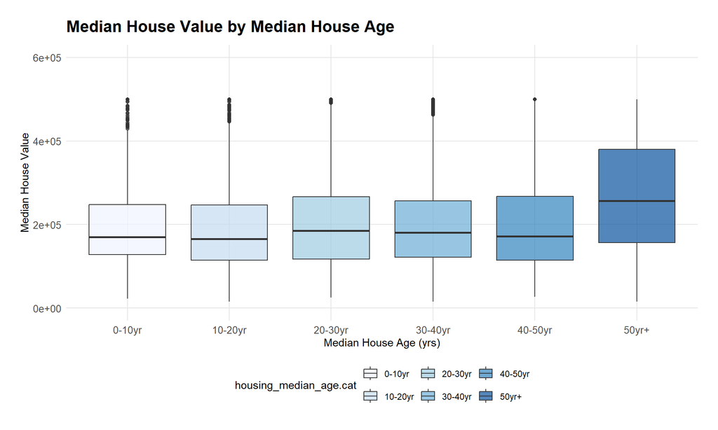

```r
boxplot1 <- ggplot(housing, aes(x = housing_median_age.cat, y = median_house_value, fill = housing_median_age.cat)) +
  geom_boxplot(alpha = 0.7) +
  coord_cartesian(ylim = c(0, 600000)) +
  labs( title = "Median House Value by Median House Age",
        x = "Median House Age (yrs)",
        y = "Median House Value") +
  theme_minimal() +
  theme( legend.position = "none",
         axis.text.x = element_text(angle = 45, hjust = 1)) +
  scale_fill_brewer(palette = "Blues") +
  theme_storytelling

boxplot1
```

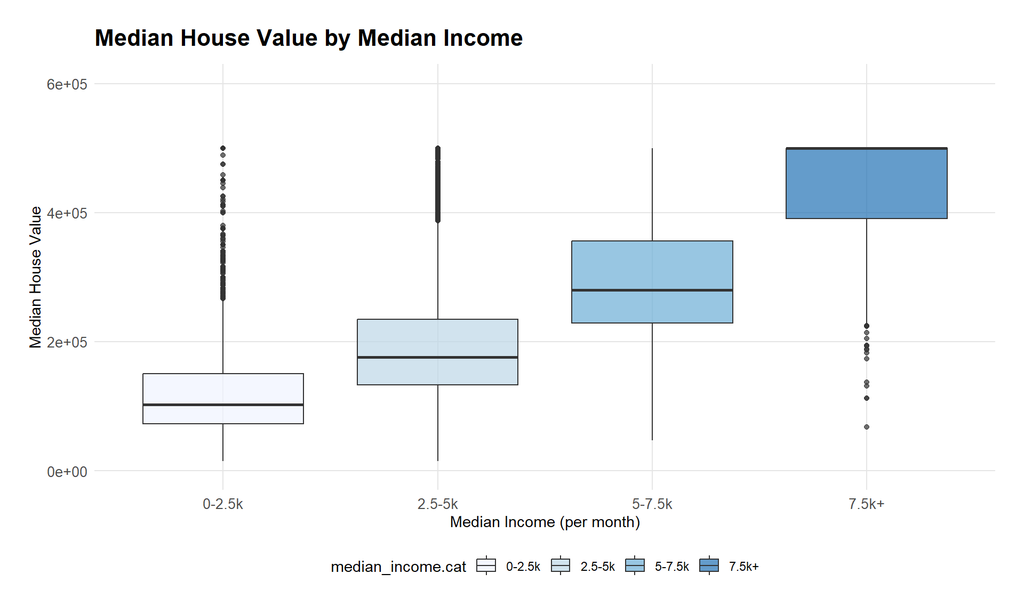

```r
boxplot2 <- ggplot(housing, aes(x = median_income.cat, y = median_house_value, fill = median_income.cat)) +
  geom_boxplot(alpha = 0.7) +
  coord_cartesian(ylim = c(0, 600000)) +
  labs( title = "Median House Value by Median Income",
        x = "Median Income (per month)",
        y = "Median House Value") +
  theme_minimal() +
  theme( legend.position = "none",
         axis.text.x = element_text(angle = 45, hjust = 1)) +
  scale_fill_brewer(palette = "Blues") +
  theme_storytelling

boxplot2
```

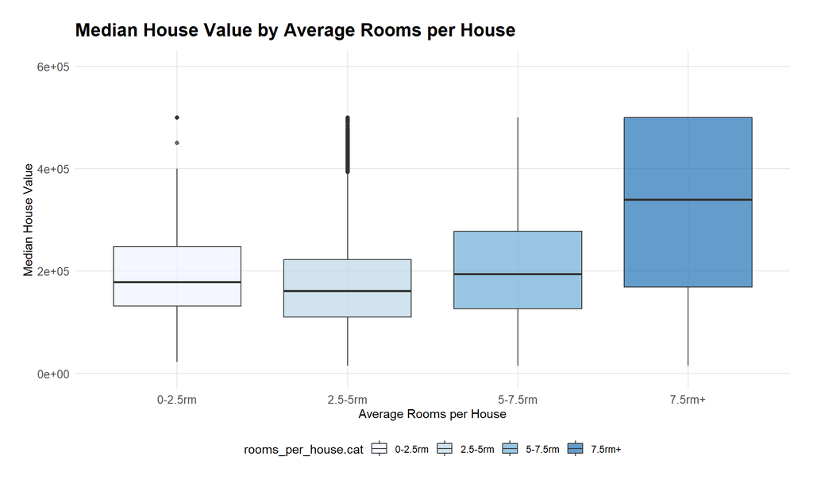

```r
boxplot3 <- ggplot(housing, aes(x = rooms_per_house.cat, y = median_house_value, fill = rooms_per_house.cat)) +
  geom_boxplot(alpha = 0.7) +
  coord_cartesian(ylim = c(0, 600000)) +
  labs( title = "Median House Value by Average Rooms per House",
        x = "Average Rooms per House",
        y = "Median House Value") +
  theme_minimal() +
  theme( legend.position = "none",
         axis.text.x = element_text(angle = 45, hjust = 1)) +
  scale_fill_brewer(palette = "Blues") +
  theme_storytelling

boxplot3
```

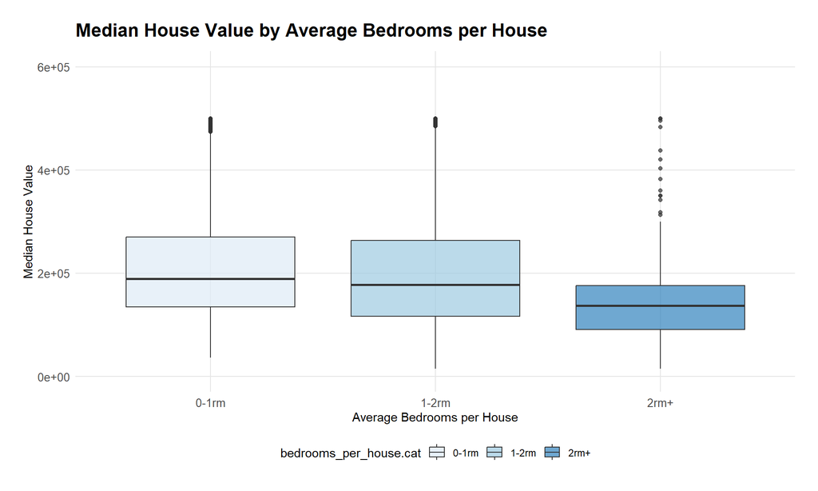

```r
boxplot4 <- ggplot(housing, aes(x = bedrooms_per_house.cat, y = median_house_value, fill = bedrooms_per_house.cat)) +
  geom_boxplot(alpha = 0.7) +
  coord_cartesian(ylim = c(0, 600000)) +
  labs( title = "Median House Value by Average Bedrooms per House",
        x = "Average Bedrooms per House",
        y = "Median House Value") +
  theme_minimal() +
  theme( legend.position = "none",
         axis.text.x = element_text(angle = 45, hjust = 1)) +
  scale_fill_brewer(palette = "Blues") +
  theme_storytelling

boxplot4
```

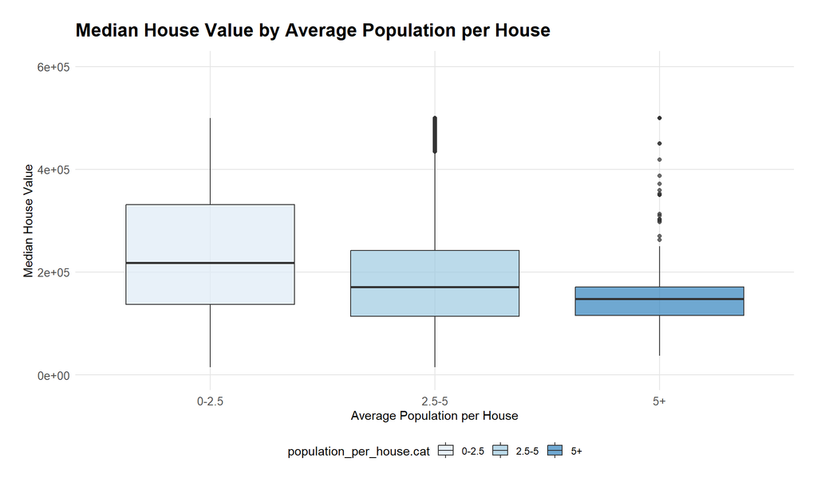

```r
boxplot5 <- ggplot(housing, aes(x = population_per_house.cat, y = median_house_value, fill = population_per_house.cat)) +
  geom_boxplot(alpha = 0.7) +
  coord_cartesian(ylim = c(0, 600000)) +
  labs( title = "Median House Value by Average Population per House",
        x = "Average Population per House",
        y = "Median House Value") +
  theme_minimal() +
  theme( legend.position = "none",
         axis.text.x = element_text(angle = 45, hjust = 1)) +
  scale_fill_brewer(palette = "Blues") +
  theme_storytelling

boxplot5
```

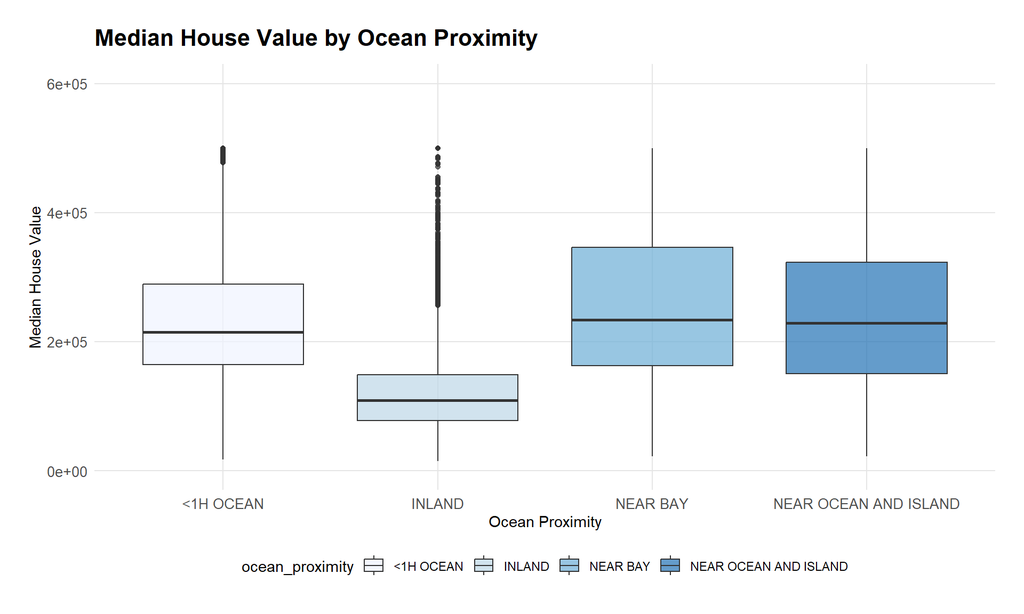

```r
boxplot6 <- ggplot(housing, aes(x = ocean_proximity, y = median_house_value, fill = ocean_proximity)) +
  geom_boxplot(alpha = 0.7) +
  coord_cartesian(ylim = c(0, 600000)) +
  labs( title = "Median House Value by Ocean Proximity",
        x = "Ocean Proximity",
        y = "Median House Value") +
  theme_minimal() +
  theme( legend.position = "none",
         axis.text.x = element_text(angle = 45, hjust = 1)) +
  scale_fill_brewer(palette = "Blues") +
  theme_storytelling

boxplot6
```

As seen in the above plots, all predictor variables appear to be associated with median house value. However, further analysis would provide useful insight.

# 4 Regression Analysis

Next we will consider a regression analysis of housing prices. The primary goal of this analysis is to identify predictor variables that are both important practically and statistically when it comes to predicting median house value within block groups.

## 4.1 Candidate Models

**Small Model:** Contains only ‘[median_income]’:

```r
housing$ocean_proximity <- factor(housing$ocean_proximity, ordered = FALSE)
housing$housing_median_age.cat <- factor(housing$housing_median_age.cat, ordered = FALSE)
housing$median_income.cat <- factor(housing$median_income.cat, ordered = FALSE)
housing$rooms_per_house.cat <- factor(housing$rooms_per_house.cat, ordered = FALSE)
housing$bedrooms_per_house.cat <- factor(housing$bedrooms_per_house.cat, ordered = FALSE)
housing$population_per_house.cat <- factor(housing$population_per_house.cat, ordered = FALSE)

housingclean <- housing[!is.na(housing$bedrooms_per_house.cat), ]

model_small <- lm(median_house_value ~ median_income.cat, data = housingclean)
pander(round(summary(model_small)$coef,5))
```

|  | Estimate | Std. Error | t value | Pr(>\|t\|) |
| --- | --- | --- | --- | --- |
| **(Intercept)** | 121317 | 1261 | 96.22 | 0 |
| **median_income.cat2.5-5k** | 73590 | 1504 | 48.92 | 0 |
| **median_income.cat5-7.5k** | 177032 | 1934 | 91.54 | 0 |
| **median_income.cat7.5k+** | 321882 | 3119 | 103.2 | 0 |

**Full Model:** Contains all predictor variables:

```r
model_full <- lm(median_house_value ~ housing_median_age.cat + median_income.cat + rooms_per_house.cat + bedrooms_per_house.cat + population_per_house.cat + ocean_proximity, data = housingclean)

pander(round(summary(model_full)$coef, 5))
```

|  | Estimate | Std. Error | t value | Pr(>\|t\|) |
| --- | --- | --- | --- | --- |
| **(Intercept)** | 205839 | 6035 | 34.11 | 0 |
| **housing_median_age.cat10-20yr** | 1868 | 2106 | 0.887 | 0.3751 |
| **housing_median_age.cat20-30yr** | 15464 | 2121 | 7.291 | 0 |
| **housing_median_age.cat30-40yr** | 18421 | 2117 | 8.702 | 0 |
| **housing_median_age.cat40-50yr** | 21332 | 2394 | 8.911 | 0 |
| **housing_median_age.cat50yr+** | 57947 | 2835 | 20.44 | 0 |
| **median_income.cat2.5-5k** | 60695 | 1355 | 44.79 | 0 |
| **median_income.cat5-7.5k** | 156647 | 1969 | 79.55 | 0 |
| **median_income.cat7.5k+** | 279486 | 3190 | 87.61 | 0 |
| **rooms_per_house.cat2.5-5rm** | -41077 | 5662 | -7.255 | 0 |
| **rooms_per_house.cat5-7.5rm** | -34944 | 5757 | -6.07 | 0 |
| **rooms_per_house.cat7.5rm+** | -2239 | 6387 | -0.3506 | 0.7259 |
| **bedrooms_per_house.cat1-2rm** | 12373 | 1232 | 10.04 | 0 |
| **bedrooms_per_house.cat2rm+** | -20562 | 5557 | -3.7 | 0.00022 |
| **population_per_house.cat2.5-5** | -51369 | 1155 | -44.49 | 0 |
| **population_per_house.cat5+** | -69438 | 3991 | -17.4 | 0 |
| **ocean_proximityINLAND** | -79352 | 1301 | -60.98 | 0 |
| **ocean_proximityNEAR BAY** | -4376 | 1781 | -2.458 | 0.01399 |
| **ocean_proximityNEAR OCEAN AND ISLAND** | 7879 | 1602 | 4.919 | 0 |

**Forward selection model:** Based on forward automatic selection method:

```r
model_forward <- step(lm(median_house_value ~ 1, data = housingclean), scope = formula(model_full), direction = "forward", trace = FALSE)
pander(round(summary(model_forward)$coef, 5))
```

|  | Estimate | Std. Error | t value | Pr(>\|t\|) |
| --- | --- | --- | --- | --- |
| **(Intercept)** | 205839 | 6035 | 34.11 | 0 |
| **median_income.cat2.5-5k** | 60695 | 1355 | 44.79 | 0 |
| **median_income.cat5-7.5k** | 156647 | 1969 | 79.55 | 0 |
| **median_income.cat7.5k+** | 279486 | 3190 | 87.61 | 0 |
| **ocean_proximityINLAND** | -79352 | 1301 | -60.98 | 0 |
| **ocean_proximityNEAR BAY** | -4376 | 1781 | -2.458 | 0.01399 |
| **ocean_proximityNEAR OCEAN AND ISLAND** | 7879 | 1602 | 4.919 | 0 |
| **population_per_house.cat2.5-5** | -51369 | 1155 | -44.49 | 0 |
| **population_per_house.cat5+** | -69438 | 3991 | -17.4 | 0 |
| **housing_median_age.cat10-20yr** | 1868 | 2106 | 0.887 | 0.3751 |
| **housing_median_age.cat20-30yr** | 15464 | 2121 | 7.291 | 0 |
| **housing_median_age.cat30-40yr** | 18421 | 2117 | 8.702 | 0 |
| **housing_median_age.cat40-50yr** | 21332 | 2394 | 8.911 | 0 |
| **housing_median_age.cat50yr+** | 57947 | 2835 | 20.44 | 0 |
| **rooms_per_house.cat2.5-5rm** | -41077 | 5662 | -7.255 | 0 |
| **rooms_per_house.cat5-7.5rm** | -34944 | 5757 | -6.07 | 0 |
| **rooms_per_house.cat7.5rm+** | -2239 | 6387 | -0.3506 | 0.7259 |
| **bedrooms_per_house.cat1-2rm** | 12373 | 1232 | 10.04 | 0 |
| **bedrooms_per_house.cat2rm+** | -20562 | 5557 | -3.7 | 0.00022 |

## 4.2 Residual Diagnostics

The residual plot, Q-Q plot, studentized residual plot, and leverage plot for our final (forward automatic selection) model:

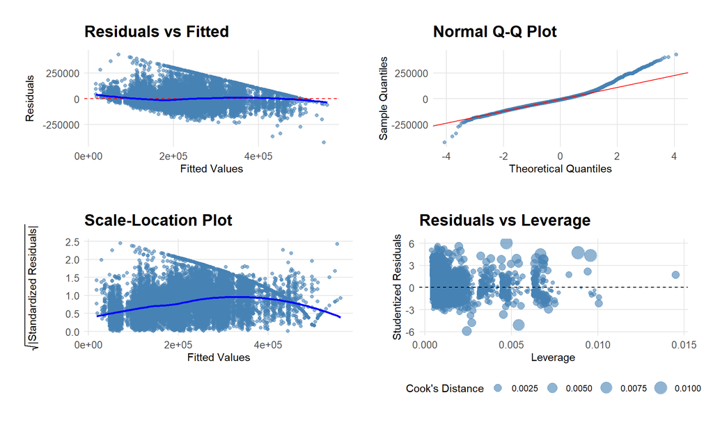

```r
# Diagnostic plots for the model_forward model
# Residuals vs Fitted using ggplot
residual_data <- data.frame(
  Fitted = fitted(model_forward),
  Residuals = residuals(model_forward),
  Standardized = rstandard(model_forward),
  Studentized = rstudent(model_forward)
)

# Residuals vs Fitted plot
r1 <- ggplot(residual_data, aes(x = Fitted, y = Residuals)) +
  geom_point(alpha = 0.6, color = "steelblue") +
  geom_hline(yintercept = 0, linetype = "dashed", color = "red") +
  geom_smooth(se = FALSE, method = "loess", color = "blue") +
  labs(title = "Residuals vs Fitted",
       x = "Fitted Values",
       y = "Residuals") +
  theme_storytelling

# Q-Q plot
r2 <- ggplot(residual_data, aes(sample = Residuals)) +
  stat_qq(alpha = 0.6, color = "steelblue") +
  stat_qq_line(color = "red") +
  labs(title = "Normal Q-Q Plot",
       x = "Theoretical Quantiles",
       y = "Sample Quantiles") +
  theme_storytelling

# Scale-Location plot
r3 <- ggplot(residual_data, aes(x = Fitted, y = sqrt(abs(Standardized)))) +
  geom_point(alpha = 0.6, color = "steelblue") +
  geom_smooth(se = FALSE, method = "loess", color = "blue") +
  labs(title = "Scale-Location Plot",
       x = "Fitted Values",
       y = expression(sqrt("|Standardized Residuals|"))) +
  theme_storytelling

# Residuals vs Leverage
# Calculate leverage and Cook's distance
leverage <- hatvalues(model_forward)
cooksd <- cooks.distance(model_forward)

residual_data$Leverage <- leverage
residual_data$CookSD <- cooksd

r4 <- ggplot(residual_data, aes(x = Leverage, y = Studentized)) +
  geom_point(aes(size = CookSD), alpha = 0.6, color = "steelblue") +
  geom_hline(yintercept = 0, linetype = "dashed") +
  labs(title = "Residuals vs Leverage",
       x = "Leverage",
       y = "Studentized Residuals") +
  theme_minimal() +
  scale_size_continuous("Cook's Distance") +
  theme_storytelling


(r1 | r2) /
(r3 | r4)
```

There does appear to be a possible violation of the normality assumption in the regression model. However, despite the violation of the normality assumption, the sufficiently large sample size (n = 20,433) ensures, via the Central Limit Theorem, that the reported p-values are approximately correct.

# 5 Summary

In this analysis, we formed a multiple linear regression model that can be used to predict median house value within a block group (in California in 1990) based on housing median age, median income, ocean proximity, average rooms per house, average bedrooms per house, and average population per house. Variables were first categorized into meaningful groups and then selected through forward stepwise selection. The final model explains a substantial proportion of the variation in median house values ($r^2=0.616$). The overall model was highly significant ($F=1821.156, p \approx 0$), suggesting that the predictors provide strong explanatory power.

**Key Predictors:**

**Median Income** Median income was the strongest predictor of median house value. Relative to block groups with median monthly incomes below 2.5k, block groups with median incomes between 2.5k and 5k had median house values approximately $60,695 higher. Furthermore, for block groups with median incomes between 5k-7.5k median house values were approximately $156,647 higher and for block groups with median incomes greater than 7.5k median house values were approximately $279,486 higher. These results indicate a strong positive relationship between block group median income and median house value which confirms our previously stated hypothesis.

**Ocean Proximity:** Ocean proximity was also an important predictor of housing value. Compared block groups less than one hour from the ocean, inland block groups had median house values approximately $79,352 lower. Block groups located near the ocean and islands exhibited significantly higher median house values, while those near bays showed slightly lower median house values, though the magnitude of this effect was relatively small.

**Average Population per Household:** Contrary to our hypothesis, average population per household was negatively associated with housing value. Relative to block groups with an average of fewer than 2.5 individuals per household, areas with an average 2.5–5 individuals per household had median house values approximately $51,369 lower, while areas with more than 5 individuals per household had values roughly $69,438 lower. This suggests that more crowded housing environments tend to be associated with lower-valued properties.

**Average Rooms per House:** The relationship between average rooms per house and median house value was somewhat mixed. Relative to block groups with fewer than an average of 2.5 rooms per house, the middle room categories were associated with significantly lower housing values. However, the highest category (an average of 7.5+ rooms per house) was not statistically significant, suggesting that average room count alone provides limited additional predictive value.

**Average Bedrooms per House:** The relationship between average bedrooms per house and median house value was also somewhat mixed. Block groups with an average of 1–2 bedrooms per house had median house values approximately $12,373 higher than the block groups with an average less than 1 room per house, while those with an average of more than 2 bedrooms per house had values approximately $20,562 lower.

**Housing Median Age:** Contrary to our hypothesis, median housing age demonstrated a generally positive relationship with median housing value. Compared to the youngest housing category (0–10 years), older housing categories were associated with higher median house values, particularly for median housing ages older than 50 years, which was associated with an increase of approximately $57,947. The 10–20 year category was not statistically significant, indicating little difference from the youngest housing group.

**Overall Conclusions:** Overall, the model indicates that economic characteristics, particularly median income, are the strongest determinants of median housing value. Similarly, location relating to the ocean and other bodies of water played an important role, with coastal block groups generally commanding substantially higher housing prices than inland areas.